# Potato Randomization Analysis

Dina Dinh

September 05, 2025

# Research Question: Did the intervention have any effect on LDL and HDL particle sizes?

## Data Cleaning and Summary Statistics

I believe subject “A00-079493” is a typo and should be “A00-07-3493” also “A00-054384” should be “A00-05-4384”. However, since it is more evident for subject “A00-05-4384”, I will only be adjusting this typo.

```
## # A tibble: 0 × 3
## # ℹ 3 variables: SubjectID <chr>, Visit <fct>, n <int>
```

|  | LMP VISIT 1 (N=17) | LMP VISIT 9 (N=17) | PLM VISIT 1 (N=18) | PLM VISIT 9 (N=14) |
| --- | --- | --- | --- | --- |
| VLDLCP3 |  |  |  |  |
| Mean (SD) | 47.0 (19.6) | 49.6 (22.8) | 43.3 (19.7) | 51.6 (23.9) |
| Median [Min, Max] | 45.8 [12.3, 81.6] | 50.1 [10.6, 87.1] | 42.1 [6.10, 80.4] | 51.9 [16.7, 94.8] |
| VLCP3 |  |  |  |  |
| Mean (SD) | 4.39 (3.54) | 4.48 (2.78) | 4.53 (4.69) | 5.09 (4.22) |
| Median [Min, Max] | 3.20 [0.600, 14.0] | 4.10 [1.00, 10.0] | 3.20 [0.500, 19.3] | 4.05 [0.200, 15.9] |
| VMP3 |  |  |  |  |
| Mean (SD) | 12.7 (8.53) | 15.7 (10.8) | 10.5 (9.66) | 17.0 (12.3) |
| Median [Min, Max] | 10.7 [2.20, 25.6] | 12.0 [0, 35.3] | 8.20 [0, 36.8] | 13.4 [0.200, 39.4] |
| VSP3 |  |  |  |  |
| Mean (SD) | 29.9 (12.7) | 29.4 (13.0) | 28.3 (14.8) | 29.6 (15.6) |
| Median [Min, Max] | 31.4 [5.60, 53.7] | 29.9 [4.60, 54.0] | 26.9 [5.50, 55.3] | 28.7 [6.70, 69.2] |
| LDLP3 |  |  |  |  |
| Mean (SD) | 1110 (215) | 1160 (255) | 1010 (297) | 1060 (289) |
| Median [Min, Max] | 1080 [812, 1560] | 1110 [841, 1820] | 1000 [507, 1780] | 1040 [657, 1540] |
| IDLP3 |  |  |  |  |
| Mean (SD) | 164 (81.7) | 203 (127) | 127 (76.0) | 239 (131) |
| Median [Min, Max] | 168 [15.0, 328] | 138 [48.0, 446] | 122 [40.0, 336] | 208 [41.0, 499] |
| LLP3 |  |  |  |  |
| Mean (SD) | 324 (203) | 255 (201) | 254 (162) | 160 (147) |
| Median [Min, Max] | 329 [0, 777] | 231 [0, 744] | 218 [0, 513] | 108 [0, 452] |
| LSP3 |  |  |  |  |
| Mean (SD) | 624 (214) | 698 (215) | 627 (204) | 657 (240) |
| Median [Min, Max] | 642 [72.0, 900] | 706 [77.0, 1100] | 654 [291, 1060] | 636 [365, 1180] |
| HDLP3 |  |  |  |  |
| Mean (SD) | 31.2 (4.74) | 27.1 (3.57) | 32.8 (6.41) | 28.9 (3.55) |
| Median [Min, Max] | 29.5 [25.1, 41.4] | 26.4 [17.7, 32.8] | 33.4 [20.5, 45.6] | 29.4 [21.5, 33.9] |
| HLP3 |  |  |  |  |
| Mean (SD) | 6.75 (2.16) | 5.66 (2.24) | 7.32 (2.78) | 6.83 (2.60) |
| Median [Min, Max] | 6.70 [3.80, 10.6] | 4.90 [3.40, 12.0] | 5.90 [3.40, 12.2] | 6.50 [3.50, 11.4] |
| HMP3 |  |  |  |  |
| Mean (SD) | 10.8 (4.96) | 9.06 (3.57) | 12.3 (7.20) | 9.94 (6.38) |
| Median [Min, Max] | 9.60 [2.90, 21.7] | 8.60 [2.80, 15.3] | 10.7 [2.70, 34.1] | 9.90 [0.800, 20.3] |
| HSP3 |  |  |  |  |
| Mean (SD) | 13.7 (5.97) | 12.4 (2.48) | 13.3 (6.10) | 12.1 (7.11) |
| Median [Min, Max] | 13.7 [0.200, 24.0] | 12.4 [7.30, 15.6] | 14.1 [0, 25.5] | 11.2 [1.50, 23.8] |
| VZ3 |  |  |  |  |
| Mean (SD) | 48.4 (6.72) | 50.0 (6.61) | 50.6 (8.99) | 49.7 (6.08) |
| Median [Min, Max] | 46.6 [37.6, 65.6] | 49.6 [40.1, 65.3] | 48.4 [37.4, 70.5] | 50.8 [37.6, 61.1] |
| Missing | 0 (0%) | 1 (5.9%) | 1 (5.6%) | 0 (0%) |
| LZ3 |  |  |  |  |
| Mean (SD) | 20.8 (0.713) | 20.4 (0.565) | 20.6 (0.530) | 20.3 (0.524) |
| Median [Min, Max] | 20.6 [19.7, 21.8] | 20.2 [19.6, 21.6] | 20.7 [19.7, 21.7] | 20.4 [19.6, 21.2] |
| HZ3 |  |  |  |  |
| Mean (SD) | 9.42 (0.443) | 9.32 (0.419) | 9.51 (0.359) | 9.46 (0.398) |
| Median [Min, Max] | 9.40 [8.80, 10.4] | 9.20 [8.90, 10.4] | 9.60 [8.80, 10.1] | 9.50 [8.90, 9.90] |
| LPIR |  |  |  |  |
| Mean (SD) | 42.4 (19.4) | 49.6 (17.1) | 44.1 (19.7) | 45.9 (17.2) |
| Median [Min, Max] | 42.0 [5.00, 81.0] | 54.0 [18.0, 84.0] | 40.0 [8.00, 82.0] | 43.0 [12.0, 74.0] |
| ELP_TC |  |  |  |  |
| Mean (SD) | 190 (26.1) | 180 (33.0) | 182 (30.3) | 182 (29.1) |
| Median [Min, Max] | 196 [144, 236] | 176 [128, 260] | 174 [118, 234] | 176 [146, 229] |
| ELP_HDLC |  |  |  |  |
| Mean (SD) | 48.2 (8.15) | 42.1 (8.79) | 50.3 (13.7) | 46.6 (10.6) |
| Median [Min, Max] | 45.0 [39.0, 62.0] | 39.0 [35.0, 69.0] | 46.5 [31.0, 76.0] | 44.0 [33.0, 63.0] |
| ELP_TG |  |  |  |  |
| Mean (SD) | 103 (48.5) | 106 (36.9) | 112 (91.8) | 111 (50.5) |
| Median [Min, Max] | 96.0 [51.0, 241] | 112 [51.0, 157] | 84.0 [42.0, 436] | 108 [54.0, 230] |
| ELP_APOB |  |  |  |  |
| Mean (SD) | 102 (13.6) | 101 (18.0) | 94.4 (15.4) | 96.1 (17.4) |
| Median [Min, Max] | 104 [75.0, 124] | 97.0 [72.0, 136] | 88.0 [73.0, 131] | 94.5 [72.0, 129] |
| ELP_LDLC |  |  |  |  |
| Mean (SD) | 123 (24.9) | 119 (28.8) | 112 (28.2) | 115 (27.3) |
| Median [Min, Max] | 130 [80.0, 158] | 115 [77.0, 179] | 103 [65.0, 174] | 108 [82.0, 166] |
| ELP_VLDLC |  |  |  |  |
| Mean (SD) | 18.6 (8.01) | 19.4 (6.19) | 19.9 (14.0) | 20.3 (8.78) |
| Median [Min, Max] | 17.0 [10.0, 40.0] | 20.0 [10.0, 28.0] | 15.5 [8.00, 68.0] | 19.5 [10.0, 41.0] |
| ELP_NONHDLC |  |  |  |  |
| Mean (SD) | 142 (23.6) | 138 (28.9) | 132 (28.6) | 136 (30.4) |
| Median [Min, Max] | 140 [101, 174] | 136 [93.0, 191] | 129 [87.0, 200] | 133 [94.0, 193] |

Since our main focus is the LDL and HDL size changes in each diet groups over time, we’ll plot those changes.

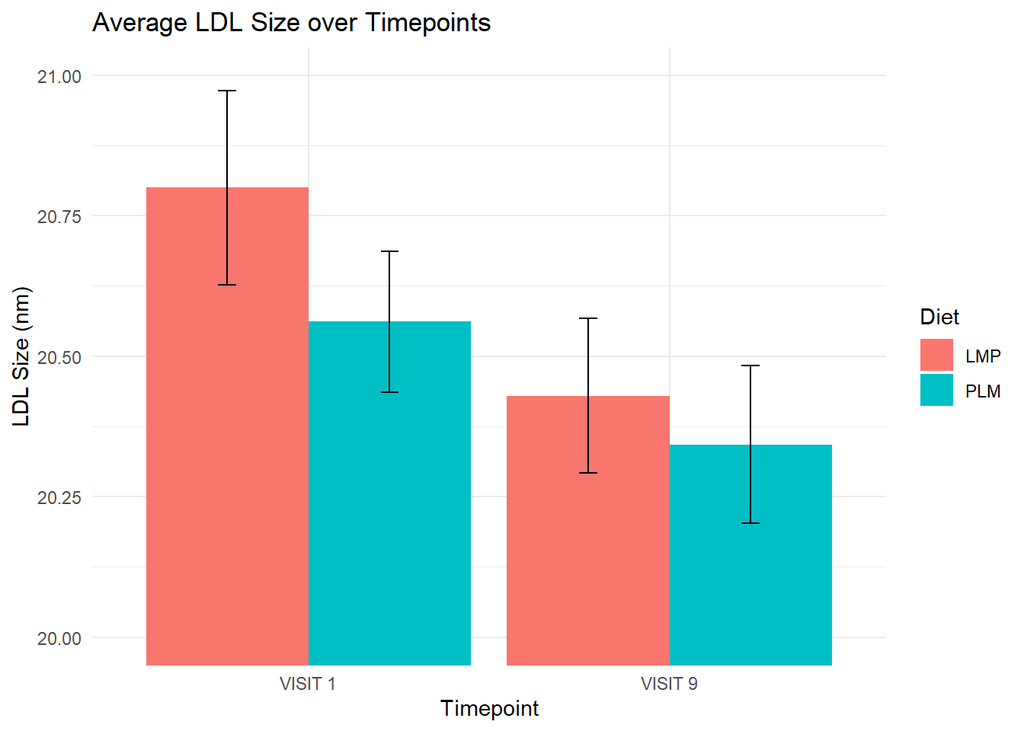

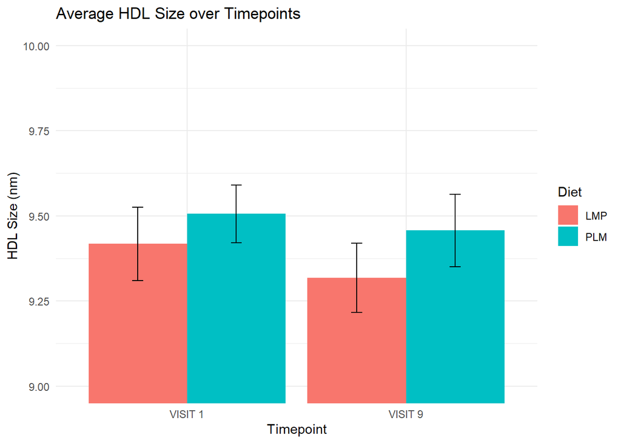

We can see that the PLM diet group has larger HDL size, but the decrease in average HDL size from visit 1 to visit 9 is visibly more in the LMP group than the PLM. Again, there are strong overlapping error bars.

## Linear Mixed Models

Here, we will be using an unstructured covariance model.

In running the model, I found that subjects “A00-01-2009” and “A00-07-8983” have two visit 1 observations recorded. I will use the most recent Visit 1 observation of those participants.

### LDL Size as the Response Variable

### Full Model

model1 = mmrm(LZ3 ~ Diet*Visit + us(Visit | SubjectID), data = df5)

#### Model Summary

```
## [1] "AIC: 110.971472797057"
```

```
## mmrm fit
##
## Formula:     LZ3 ~ Diet * Visit + us(Visit | SubjectID)
## Data:        df5 (used 66 observations from 36 subjects with maximum 2
## timepoints)
## Covariance:  unstructured (3 variance parameters)
## Method:      Satterthwaite
## Vcov Method: Asymptotic
## Inference:   REML
##
## Model selection criteria:
##      AIC      BIC   logLik deviance
##    111.0    115.7    -52.5    105.0
##
## Coefficients:
##                      Estimate Std. Error      df t value Pr(>|t|)
## (Intercept)           20.7733     0.1502 33.9700 138.330  < 2e-16 ***
## DietPLM               -0.2122     0.2107 33.5200  -1.007  0.32112
## VisitVISIT 9          -0.3770     0.1203 29.4800  -3.135  0.00387 **
## DietPLM:VisitVISIT 9   0.1114     0.1740 30.3100   0.641  0.52658
## ---
## Signif. codes:  0 '***' 0.001 '**' 0.01 '*' 0.05 '.' 0.1 ' ' 1
##
## Covariance estimate:
##         VISIT 1 VISIT 9
## VISIT 1  0.3930  0.2273
## VISIT 9  0.2273  0.2983
```

#### Type III Test

```
## Analysis of Fixed Effect Table (Type III F tests)
##            Num Df Denom Df F Statistic   Pr(>=F)
## Diet            1   33.901      0.7462 0.3937534
## Visit           1   30.314     13.6432 0.0008696 ***
## Diet:Visit      1   30.314      0.4104 0.5265786
## ---
## Signif. codes:  0 '***' 0.001 '**' 0.01 '*' 0.05 '.' 0.1 ' ' 1
```

Here, the type III test is testing if

1. $Diet_L$ = $Diet_P$
2. $Visit_1$ = $Visit_9$
3. ($Diet_9,_L$ - $Diet_1,_L$) = ($Diet_9,_P$ - $Diet_1,_P$)

These are possibles useful tests for the researchers.

```
##
##  Shapiro-Wilk normality test
##
## data:  residuals(model1)
## W = 0.97645, p-value = 0.2415
```

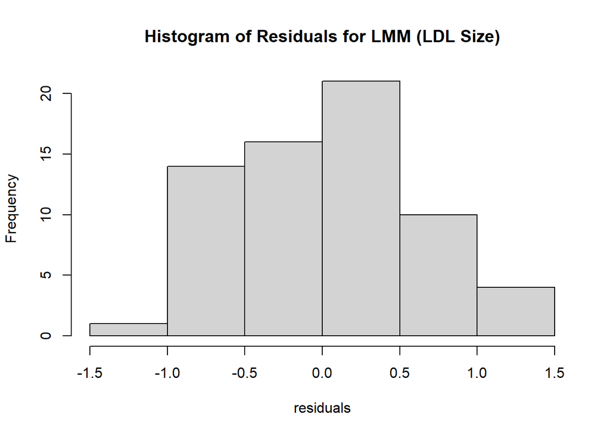

#### Bar Charts

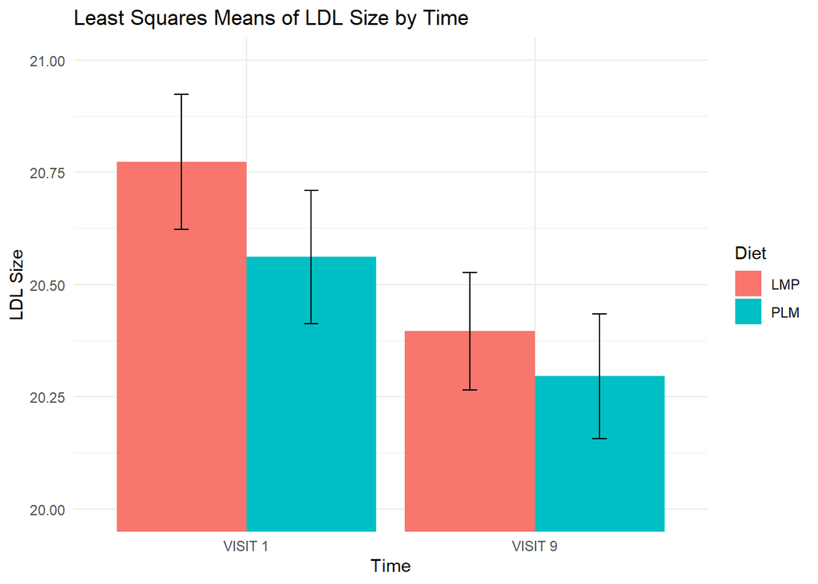

#### Estimates

| Diet | Visit | estimate | SE |
| --- | --- | --- | --- |
| LMP | VISIT 1 | 20.77327 | 0.1501719 |
| PLM | VISIT 1 | 20.56111 | 0.1477577 |
| LMP | VISIT 9 | 20.39629 | 0.1308452 |
| PLM | VISIT 9 | 20.29557 | 0.1386458 |

#### Tests

| contrast | estimate | SE | df | t.ratio | p.value |
| --- | --- | --- | --- | --- | --- |
| Visit 1 Difference | -0.2121619 | 0.2106750 | 33.52137 | -1.0070580 | 0.3211213 |
| LMP: Visit 9 - Visit 1 | -0.3769791 | 0.1202605 | 29.48360 | -3.1346885 | 0.0038748 |
| PLM: Visit 9 - Visit 1 | -0.2655412 | 0.1256842 | 30.91989 | -2.1127640 | 0.0427958 |
| LMP vs PLM: Visit 9 - Visit 1 | 0.1114380 | 0.1739515 | 30.31398 | 0.6406268 | 0.5265786 |

### Reduced Model

model1.2 = mmrm(LZ3 ~ Diet:Visit + us(Visit | SubjectID), data = df5)

#### Model Summary

```
## [1] "AIC: 110.971472797115"
```

```
## mmrm fit
##
## Formula:     LZ3 ~ 0 + Diet:Visit + us(Visit | SubjectID)
## Data:        df5 (used 66 observations from 36 subjects with maximum 2
## timepoints)
## Covariance:  unstructured (3 variance parameters)
## Method:      Satterthwaite
## Vcov Method: Asymptotic
## Inference:   REML
##
## Model selection criteria:
##      AIC      BIC   logLik deviance
##    111.0    115.7    -52.5    105.0
##
## Coefficients:
##                      Estimate Std. Error      df t value Pr(>|t|)
## DietLMP:VisitVISIT 1  20.7733     0.1502 33.9700   138.3   <2e-16 ***
## DietPLM:VisitVISIT 1  20.5611     0.1478 33.0500   139.2   <2e-16 ***
## DietLMP:VisitVISIT 9  20.3963     0.1308 30.7800   155.9   <2e-16 ***
## DietPLM:VisitVISIT 9  20.2956     0.1386 33.2600   146.4   <2e-16 ***
## ---
## Signif. codes:  0 '***' 0.001 '**' 0.01 '*' 0.05 '.' 0.1 ' ' 1
##
## Covariance estimate:
##         VISIT 1 VISIT 9
## VISIT 1  0.3930  0.2273
## VISIT 9  0.2273  0.2983
```

#### Type III Test

```
## Analysis of Fixed Effect Table (Type III F tests)
##            Num Df Denom Df F Statistic  Pr(>=F)
## Diet:Visit      3   35.056      4.8833 0.006108 **
## ---
## Signif. codes:  0 '***' 0.001 '**' 0.01 '*' 0.05 '.' 0.1 ' ' 1
```

Here, the type III test is testing if $\mu_1,_L$ = $\mu_1,_P$ = $\mu_9,_L$ = $\mu_9,_p$ = 0. **The numerator DF and Denominator DF is different from R than SAS and it’s probably due to mmrm() DF approximation algorithm.**

This is not a useful test is this case because LDL cannot be negative.

```
##
##  Shapiro-Wilk normality test
##
## data:  residuals(model1.2)
## W = 0.97645, p-value = 0.2415
```

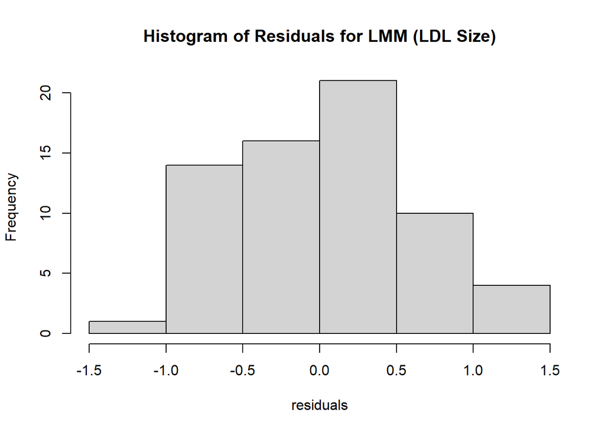

#### Bar Charts

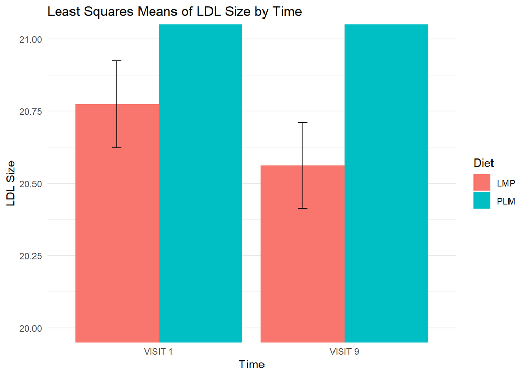

#### Estimates

| Diet | Visit | estimate | SE |
| --- | --- | --- | --- |
| LMP | VISIT 1 | 20.77327 | 0.1501719 |
| PLM | VISIT 1 | 41.16957 | 0.2547186 |
| LMP | VISIT 9 | 20.56111 | 0.1477577 |
| PLM | VISIT 9 | 40.85668 | 0.2575140 |

### HDL Size as the Response Variable

model1 = mmrm(HZ3 ~ Diet*Visit + us(Visit | SubjectID), data = df5)

```
##
##  Shapiro-Wilk normality test
##
## data:  residuals(model1)
## W = 0.9611, p-value = 0.03681
```

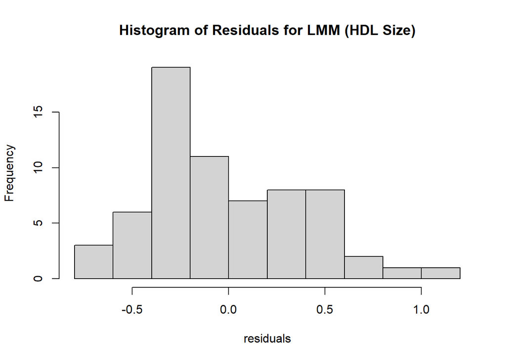

Although the Shapiro-Wilk test indicates that the residuals are not normally distributed, the histogram suggests that the residuals largely follow a normal distribution, with only a few outliers and is not heavily skewed. As such, the results of this analysis are expected to remain reliable despite the Shapiro-Wilk test’s indication of non-normality.

#### Bar Charts

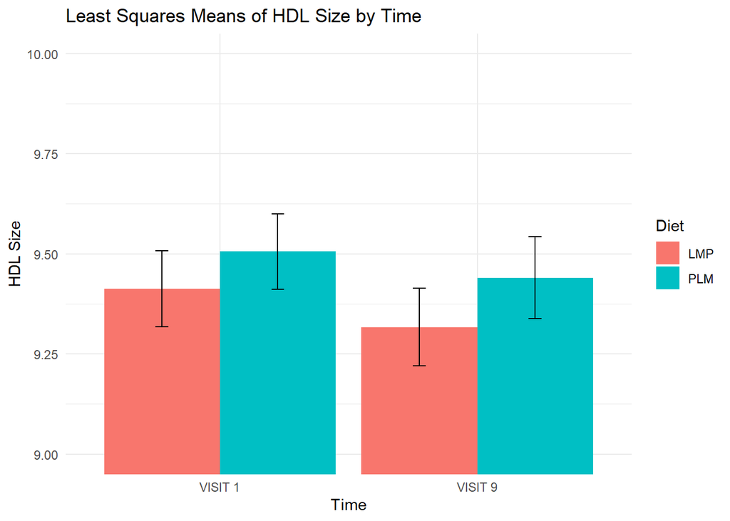

#### Estimates

| Diet | Visit | estimate | SE |
| --- | --- | --- | --- |
| LMP | VISIT 1 | 9.412767 | 0.0954128 |
| PLM | VISIT 1 | 9.505556 | 0.0940908 |
| LMP | VISIT 9 | 9.317096 | 0.0970987 |
| PLM | VISIT 9 | 9.440256 | 0.1021110 |

#### Tests

| contrast | estimate | SE | df | t.ratio | p.value |
| --- | --- | --- | --- | --- | --- |
| Visit 1 Difference | 0.0927883 | 0.1340026 | 34.19502 | 0.6924368 | 0.4933389 |
| LMP: Visit 9 - Visit 1 | -0.0956712 | 0.0745800 | 29.38733 | -1.2828001 | 0.2095879 |
| PLM: Visit 9 - Visit 1 | -0.0652997 | 0.0793001 | 29.70097 | -0.8234502 | 0.4168153 |
| LMP vs PLM: Visit 9 - Visit 1 | 0.0303715 | 0.1088608 | 29.61986 | 0.2789936 | 0.7821885 |

# 09/05/2025: Comparing Models

## Comparing AICs

| Model | AIC |
| --- | --- |
| Full Model | 59.74853 |
| Visit Main Effect and Interaction | 59.74853 |
| Diet Main Effect and Interaction | 59.74853 |
| No intercept and Interaction | 59.74853 |

## Comparing Model Summaries

### Full Model

```
## mmrm fit
##
## Formula:     HZ3 ~ Diet * Visit + us(Visit | SubjectID)
## Data:        df5 (used 66 observations from 36 subjects with maximum 2
## timepoints)
## Covariance:  unstructured (3 variance parameters)
## Method:      Satterthwaite
## Vcov Method: Asymptotic
## Inference:   REML
##
## Model selection criteria:
##      AIC      BIC   logLik deviance
##     59.7     64.5    -26.9     53.7
##
## Coefficients:
##                      Estimate Std. Error       df t value Pr(>|t|)
## (Intercept)           9.41277    0.09541 34.66000  98.653   <2e-16 ***
## DietPLM               0.09279    0.13400 34.20000   0.692    0.493
## VisitVISIT 9         -0.09567    0.07458 29.39000  -1.283    0.210
## DietPLM:VisitVISIT 9  0.03037    0.10886 29.62000   0.279    0.782
## ---
## Signif. codes:  0 '***' 0.001 '**' 0.01 '*' 0.05 '.' 0.1 ' ' 1
##
## Covariance estimate:
##         VISIT 1 VISIT 9
## VISIT 1  0.1594  0.1169
## VISIT 9  0.1169  0.1650
```

### Visit Main Effect and Interaction

```
## mmrm fit
##
## Formula:     HZ3 ~ Visit + Diet:Visit + us(Visit | SubjectID)
## Data:        df5 (used 66 observations from 36 subjects with maximum 2
## timepoints)
## Covariance:  unstructured (3 variance parameters)
## Method:      Satterthwaite
## Vcov Method: Asymptotic
## Inference:   REML
##
## Model selection criteria:
##      AIC      BIC   logLik deviance
##     59.7     64.5    -26.9     53.7
##
## Coefficients:
##                      Estimate Std. Error       df t value Pr(>|t|)
## (Intercept)           9.41277    0.09541 34.66000  98.653   <2e-16 ***
## VisitVISIT 9         -0.09567    0.07458 29.39000  -1.283    0.210
## VisitVISIT 1:DietPLM  0.09279    0.13400 34.20000   0.692    0.493
## VisitVISIT 9:DietPLM  0.12316    0.14091 32.93000   0.874    0.388
## ---
## Signif. codes:  0 '***' 0.001 '**' 0.01 '*' 0.05 '.' 0.1 ' ' 1
##
## Covariance estimate:
##         VISIT 1 VISIT 9
## VISIT 1  0.1594  0.1169
## VISIT 9  0.1169  0.1650
```

### Diet Main Effect and Interaction

```
## mmrm fit
##
## Formula:     HZ3 ~ Diet + Diet:Visit + us(Visit | SubjectID)
## Data:        df5 (used 66 observations from 36 subjects with maximum 2
## timepoints)
## Covariance:  unstructured (3 variance parameters)
## Method:      Satterthwaite
## Vcov Method: Asymptotic
## Inference:   REML
##
## Model selection criteria:
##      AIC      BIC   logLik deviance
##     59.7     64.5    -26.9     53.7
##
## Coefficients:
##                      Estimate Std. Error       df t value Pr(>|t|)
## (Intercept)           9.41277    0.09541 34.66000  98.653   <2e-16 ***
## DietPLM               0.09279    0.13400 34.20000   0.692    0.493
## DietLMP:VisitVISIT 9 -0.09567    0.07458 29.39000  -1.283    0.210
## DietPLM:VisitVISIT 9 -0.06530    0.07930 29.70000  -0.823    0.417
## ---
## Signif. codes:  0 '***' 0.001 '**' 0.01 '*' 0.05 '.' 0.1 ' ' 1
##
## Covariance estimate:
##         VISIT 1 VISIT 9
## VISIT 1  0.1594  0.1169
## VISIT 9  0.1169  0.1650
```

### No intercept and Interaction

```
## mmrm fit
##
## Formula:     HZ3 ~ 0 + Diet:Visit + us(Visit | SubjectID)
## Data:        df5 (used 66 observations from 36 subjects with maximum 2
## timepoints)
## Covariance:  unstructured (3 variance parameters)
## Method:      Satterthwaite
## Vcov Method: Asymptotic
## Inference:   REML
##
## Model selection criteria:
##      AIC      BIC   logLik deviance
##     59.7     64.5    -26.9     53.7
##
## Coefficients:
##                      Estimate Std. Error       df t value Pr(>|t|)
## DietLMP:VisitVISIT 1  9.41277    0.09541 34.66000   98.65   <2e-16 ***
## DietPLM:VisitVISIT 1  9.50556    0.09409 33.72000  101.03   <2e-16 ***
## DietLMP:VisitVISIT 9  9.31710    0.09710 31.48000   95.95   <2e-16 ***
## DietPLM:VisitVISIT 9  9.44026    0.10211 34.19000   92.45   <2e-16 ***
## ---
## Signif. codes:  0 '***' 0.001 '**' 0.01 '*' 0.05 '.' 0.1 ' ' 1
##
## Covariance estimate:
##         VISIT 1 VISIT 9
## VISIT 1  0.1594  0.1169
## VISIT 9  0.1169  0.1650
```

## Comparing Type III Tests

### Full Model

Here, the type III test is testing if

1. $Diet_L$ = $Diet_P$
2. $Visit_1$ = $Visit_9$
3. ($Diet_9,_L$ - $Diet_1,_L$) = ($Diet_9,_P$ - $Diet_1,_P$)

These are possibles useful tests for the researchers.

```
## Analysis of Fixed Effect Table (Type III F tests)
##            Num Df Denom Df F Statistic Pr(>=F)
## Diet            1   34.303     0.73125  0.3984
## Visit           1   29.620     2.18651  0.1498
## Diet:Visit      1   29.620     0.07784  0.7822
```

### Visit Main Effect and Interaction

Here, the type III test is testing if

1. $Visit_1$ = $Visit_9$
2. ???

```
## Analysis of Fixed Effect Table (Type III F tests)
##            Num Df Denom Df F Statistic Pr(>=F)
## Visit           1   29.620     2.18651  0.1498
## Visit:Diet      2   31.981     0.38993  0.6803
```

### Diet Main Effect and Interaction

Here, the type III test is testing if

1. $Diet_L$ = $Diet_P$
2. ???

```
## Analysis of Fixed Effect Table (Type III F tests)
##            Num Df Denom Df F Statistic Pr(>=F)
## Diet            1   34.303     0.73125  0.3984
## Diet:Visit      2   29.543     1.16182  0.3268
```

### No Intercept and Interaction

Here, the type III test is testing if $\mu_1,_L$ = $\mu_1,_P$ = $\mu_9,_L$ = $\mu_9,_p$ = 0. **The numerator DF and Denominator DF is different from R than SAS and it’s probably due to mmrm() DF approximation algorithm.**

This is not a useful test is this case because HDL cannot be negative.

```
## Analysis of Fixed Effect Table (Type III F tests)
##            Num Df Denom Df F Statistic Pr(>=F)
## Diet:Visit      3   33.448      1.0449  0.3854
```

## Comparing LSMeans

### Full Model

| Diet | Visit | estimate | SE |
| --- | --- | --- | --- |
| LMP | VISIT 1 | 9.412767 | 0.0954128 |
| PLM | VISIT 1 | 9.505556 | 0.0940908 |
| LMP | VISIT 9 | 9.317096 | 0.0970987 |
| PLM | VISIT 9 | 9.440256 | 0.1021110 |

### Visit Main Effect and Interaction

| Diet | Visit | estimate | SE |
| --- | --- | --- | --- |
| LMP | VISIT 1 | 9.412767 | 0.0954128 |
| PLM | VISIT 1 | 9.505556 | 0.0940908 |
| LMP | VISIT 9 | 9.317096 | 0.0970987 |
| PLM | VISIT 9 | 9.440256 | 0.1021110 |

### Diet Main Effect and Interaction

[output not shown]

### No Intercept and Interaction

For some reason, the means of the PLM diet group is doubled here.

| Diet | Visit | estimate | SE |
| --- | --- | --- | --- |
| LMP | VISIT 1 | 9.412767 | 0.0954128 |
| PLM | VISIT 1 | 18.729863 | 0.1774862 |
| LMP | VISIT 9 | 9.505556 | 0.0940908 |
| PLM | VISIT 9 | 18.945811 | 0.1796412 |

# What does it mean for the model to be the same?

The model is the same when you can get the same means from the model parameters and the relationship between predictor and response are the same for each model (units of predictors do not affect the models).